# Data Science Capstone - Milestone Report

Elizabeth Storm

February 27, 2019

Synoposis: This document was created to meet the requirements of the Milestone Report required for the Data Science Capstone on Coursera. The goal of this project is just to display that I’ve gotten used to working with the data and that I am on track to create my prediction algorithm.

## Basic Data Step Up and Summary

At the onset it is important to download the data and do some basic checks on the files. This is helpful just in part to understand the size of the data in comparison to your own computing power. I am running my analysis on my local machine, so I am going to be limited in the size of my data that I’ll be able to work with.

```r
#load libraries
library(NLP);library(tm);library(R.utils); library(stringi)
library(ggplot2); library(knitr);  library(RWeka)

#download the data
setwd("~/R/Capstone work")
if(!file.exists("Coursera-SwiftKey.zip")){
        url <- "https://d396qusza40orc.cloudfront.net/dsscapstone/dataset/Coursera-SwiftKey.zip"
        download.file(url,"Coursera-SwiftKey.zip")
        unzip("Coursera-SwiftKey.zip")
}
```

It is helpful to understand a bit of the high level details on what we downloaded. This table outlines names of the files and their sizes. I also broke out what language each it in.

```r
#take a look at what has been downloaded
zipfile_meta <- unzip("Coursera-SwiftKey.zip", list = T)
zipfile_meta <- zipfile_meta[zipfile_meta$Length>0,]
zipfile_meta$Language <- substr(zipfile_meta$Name, 7, 8)
print(zipfile_meta)
```

```
##                             Name    Length                Date Language
## 3  final/de_DE/de_DE.twitter.txt  75578341 2014-07-22 10:11:00       de
## 4    final/de_DE/de_DE.blogs.txt  85459666 2014-07-22 10:11:00       de
## 5     final/de_DE/de_DE.news.txt  95591959 2014-07-22 10:11:00       de
## 7    final/ru_RU/ru_RU.blogs.txt 116855835 2014-07-22 10:12:00       ru
## 8     final/ru_RU/ru_RU.news.txt 118996424 2014-07-22 10:12:00       ru
## 9  final/ru_RU/ru_RU.twitter.txt 105182346 2014-07-22 10:12:00       ru
## 11 final/en_US/en_US.twitter.txt 167105338 2014-07-22 10:12:00       en
## 12    final/en_US/en_US.news.txt 205811889 2014-07-22 10:13:00       en
## 13   final/en_US/en_US.blogs.txt 210160014 2014-07-22 10:13:00       en
## 15    final/fi_FI/fi_FI.news.txt  94234350 2014-07-22 10:11:00       fi
## 16   final/fi_FI/fi_FI.blogs.txt 108503595 2014-07-22 10:12:00       fi
## 17 final/fi_FI/fi_FI.twitter.txt  25331142 2014-07-22 10:10:00       fi
```

Moving foward, I am only interested in the US files. As a result of reviewing this table, I know I am going to have to sample the datasets.I want to take roughly even amounts of words from each, so I am varying my sampling methods from each dataset to result in a small enough file to work with going forward.

```r
#create a sample dataset for US Twitter Data
con_file <-file("final/en_US/en_US.twitter.txt","r")
us_twitter <- readLines(con_file, skipNul = TRUE, encoding = "UTF-8")
set.seed(888)
sample_twitter1 <-us_twitter[rbinom(length(us_twitter)*0.0025,length(us_twitter),0.1)]
sample_twitter <- iconv(sample_twitter1, 'UTF-8', 'ASCII') #needed to remove emoji
writeLines(sample_twitter, con="US_Twitter_Sample.txt")
close(con_file)
#create a sample dataset for US Blogs Data
con_file <-file("final/en_US/en_US.blogs.txt","r")
us_blogs <- readLines(con_file, skipNul = TRUE, encoding = "UTF-8")
set.seed(888)
sample_blogs <-us_blogs[rbinom(length(us_blogs)*0.001,length(us_blogs),0.1)]
writeLines(sample_blogs, con="US_Blogs_Sample.txt")
close(con_file)
#create a sample dataset for US News Data
con_file <-file("final/en_US/en_US.news.txt","r")
us_news <- readLines(con_file, skipNul = TRUE, encoding = "UTF-8")
set.seed(888)
sample_news <-us_news[rbinom(length(us_news)*0.01,length(us_news),0.1)]
writeLines(sample_news, con="US_News_Sample.txt")
close(con_file)

#merge sample data
sample_data <- paste(sample_blogs, sample_news, sample_twitter)
```

Here is a summarized table showing the original datasets versus the samples taken.

```r
# file sizes
fs_twitter <- file.info("final/en_US/en_US.twitter.txt")$size
fs_blogs   <- file.info("final/en_US/en_US.blogs.txt")$size
fs_news    <- file.info("final/en_US/en_US.news.txt")$size
fs_stwitter <- file.info("US_Twitter_Sample.txt")$size
fs_sblogs   <- file.info("US_Blogs_Sample.txt")$size
fs_snews    <- file.info("US_News_Sample.txt")$size

fs <- c(fs_twitter, fs_blogs, fs_news, fs_stwitter, fs_sblogs, fs_snews )

# line counts
lc_twitter <- length(us_twitter)
lc_blogs   <- length(us_blogs)
lc_news    <- length(us_news)
lc_stwitter <- length(sample_twitter)
lc_sblogs   <- length(sample_blogs)
lc_snews    <- length(sample_news)

lc <- c( lc_twitter, lc_blogs, lc_news, lc_stwitter, lc_sblogs, lc_snews)

# word counts
wc_twitter <- sum(stri_count_words(us_twitter))
wc_blogs   <- sum(stri_count_words(us_blogs))
wc_news    <- sum(stri_count_words(us_news))
wc_stwitter <- sum(stri_count_words(sample_twitter1))
wc_sblogs   <- sum(stri_count_words(sample_blogs))
wc_snews    <- sum(stri_count_words(sample_news))

wc <- c( wc_twitter, wc_blogs, wc_news, wc_stwitter, wc_sblogs, wc_snews)

dset_names <- c("twitter","blogs", "news","sample_twitter","sample_blogs", "sample_news")
stat <- data.frame(dset_names, fs, lc, wc)
colnames(stat) <- c("Dataset names", "Size in bytes", "Line count", "Word count")
kable(stat, format="markdown", caption = "Basic statistics of the datasets")
```

| Dataset names | Size in bytes | Line count | Word count |
| --- | --- | --- | --- |
| twitter | 167105338 | 2360148 | 30093410 |
| blogs | 210160014 | 899288 | 37546246 |
| news | 205811889 | 77259 | 2674536 |
| sample_twitter | 400475 | 5900 | 75027 |
| sample_blogs | 217504 | 899 | 39123 |
| sample_news | 156732 | 772 | 26473 |

## Creating the Corpus and Tokenization

We are now ready to create the corpus (https://en.wikipedia.org/wiki/Text_corpus) which is the cleaned up, structured version of the data. Included below are steps to remove punctuation and numbers, move to lower case, and remove white space. I thought about stopwords and stemming, but since I am building a tool to predict the next words given the prior words, I actually decided I don’t want to exclude these items. You cannot make sentences be coherent without stop words. I did however remove profanity. Keep it clean people!

```r
##Make corpus
corpus <- VCorpus(VectorSource(sample_data))

corpus <- tm_map(corpus, removePunctuation)                 # Remove punctuation
corpus <- tm_map(corpus, removeNumbers)                     # Remove numbers
corpus <- tm_map(corpus, tolower)                           # Convert to lower case
#corpus <- tm_map(corpus, removeWords, stopwords(kind="en")) # Remove (English) stopwords
#corpus <- tm_map(corpus, stemDocument)                      # Do stemming
corpus <- tm_map(corpus, stripWhitespace)                   # Remove (remaining) whitespace
corpus <- tm_map(corpus, PlainTextDocument)                 # Process as text documents

##Profanity filter
if(!file.exists("swearWords.txt")){
        url <- "http://www.bannedwordlist.com/lists/swearWords.txt"
        download.file(url,"swearWords.txt")
}
profanity_list <- readLines("swearWords.txt")
corpus <- tm_map(corpus, removeWords, profanity_list)
```

Now I am going to Tokenize (https://en.wikipedia.org/wiki/Lexical_analysis#Tokenization) the corpus for single words, 2-grams, and 3-grams.

```r
##Tokanization
UnigramTokenizer   <- function(x) NGramTokenizer(x, Weka_control(min = 1, max = 1))
BigramTokenizer   <- function(x) NGramTokenizer(x, Weka_control(min = 2, max = 2))
TrigramTokenizer <- function(x) NGramTokenizer(x, Weka_control(min = 3, max = 3))

dtm_uni   <- DocumentTermMatrix(corpus, control=list(tokenize=UnigramTokenizer))
dtm_bi   <- DocumentTermMatrix(corpus, control=list(tokenize=BigramTokenizer))
dtm_tri <- DocumentTermMatrix(corpus, control=list(tokenize=TrigramTokenizer))
```

## Data Visualization of the Results

The next helpful step will be to review the resulting data in a summarized manner to get a feel for it.

```r
##calculate frequency
uni_frequency   <- sort(colSums(as.matrix(dtm_uni)), decreasing=TRUE)
bi_frequency   <- sort(colSums(as.matrix(dtm_bi)), decreasing=TRUE)
tri_frequency <- sort(colSums(as.matrix(dtm_tri)), decreasing=TRUE)

#produce quantiles
Uniquant <- quantile(uni_frequency,probs=c(0,25,50,75,90,95,99,100)/100)
Uniquant
```

```
##    0%   25%   50%   75%   90%   95%   99%  100%
##     1     6    12    27    63   110   418 26584
```

```r
biquant <- quantile(bi_frequency,probs=c(0,25,50,75,90,95,99,100)/100)
biquant
```

```
##   0%  25%  50%  75%  90%  95%  99% 100%
##    1    1    6   13   23   34   69 2564
```

```r
triquant <- quantile(tri_frequency,probs=c(0,25,50,75,90,95,99,100)/100)
triquant
```

```
##    0%   25%   50%   75%   90%   95%   99%  100%
##   1.0   1.0   5.0   8.0  16.0  24.0  41.3 223.0
```

I am also going to look at the distribution plots across the top 30 unique tokens for each N gram.

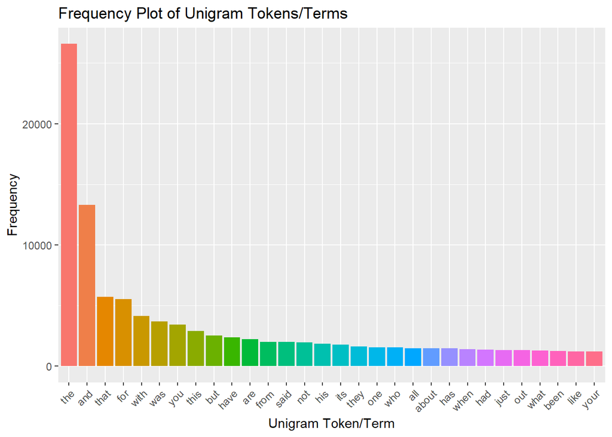

```r
##calculate plots
Uni_df <- as.data.frame(uni_frequency[1:30])
colnames(Uni_df) <- c("freq")
Uni_df$term <- rownames(Uni_df)
Uni_df$term <- factor(Uni_df$term, levels=Uni_df$term[order(-Uni_df$freq)])
ugp <- ggplot(subset(Uni_df, Uni_df$freq>30), aes(term, freq, fill=term))
ugp <- ugp + geom_bar(stat="identity")+
        ggtitle("Frequency Plot of Unigram Tokens/Terms")+
        xlab("Unigram Token/Term")+
        ylab("Frequency")+
        theme(axis.text.x=element_text(angle=45, hjust=1))+
        theme(legend.position = "none")
ugp
```

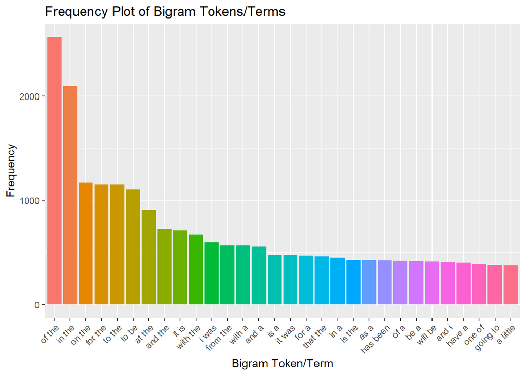

```r
bi_df <- as.data.frame(bi_frequency[1:30])
colnames(bi_df) <- c("freq")
bi_df$term <- rownames(bi_df)
bi_df$term <- factor(bi_df$term, levels=bi_df$term[order(-bi_df$freq)])

bgp <- ggplot(subset(bi_df, bi_df$freq>30), aes(term, freq, fill=term))
bgp <- bgp + geom_bar(stat="identity")+
        ggtitle("Frequency Plot of Bigram Tokens/Terms")+
        xlab("Bigram Token/Term")+
        ylab("Frequency")+
        theme(axis.text.x=element_text(angle=45, hjust=1))+
        theme(legend.position = "none")
bgp
```

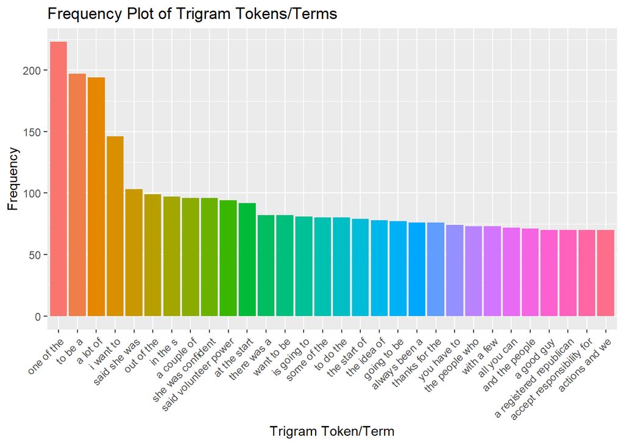

```r
tri_df <- as.data.frame(tri_frequency[1:30])
colnames(tri_df) <- c("freq")
tri_df$term <- rownames(tri_df)
tri_df$term <- factor(tri_df$term, levels=tri_df$term[order(-tri_df$freq)])

tgp <- ggplot(subset(tri_df, tri_df$freq>30), aes(term, freq, fill=term))
tgp <- tgp + geom_bar(stat="identity")+
        ggtitle("Frequency Plot of Trigram Tokens/Terms")+
        xlab("Trigram Token/Term")+
        ylab("Frequency")+
        theme(axis.text.x=element_text(angle=45, hjust=1))+
        theme(legend.position = "none")
tgp
```

## Takeaways and Next Steps

As I think about building towards the final project, this Milestone Report process helped me understand that I am really going to have to think about file size and processing time. The datasets provided are huge, and more data could provide better results, but my computer has limited memory. Also, for the end user, there is a limit to the amount of wait time people will accept before they abandon a tool. I will want to keep these two items front and center as I proceed forward.

I am planning the following for next steps: 1. Build a Training / Validation / Holdout set. 2. Start with testing a prediction algorithm that is basic, then expand to allow for inputs of words that do not appear in the modeling dataset. 3. Iterate between training and validating my model to refine it. 4. Evaluate my model on Holdout. 5. Build my Shiny App as a platform for the model. 6. Develop the Pitch presentation for the App.